# Структура научной презентации

Простейший шаблон

Царёв Максим Александрович

Российский университет дружбы народов, Москва, Россия

Объединённый институт ядерных исследований, Дубна, Россия

## Цель работы

Целью данной работы является приобретение практических навыков установки операционной системы на виртуальную машину, настройки минимально необходимых для дальнейшей работы сервисов.

## Задание

Установка виртуальной машины

## Создание виртуальной машины

[figure not shown]

## Установливаю машину на диск

[figure not shown]

[figure not shown]

## Установка средств разработки

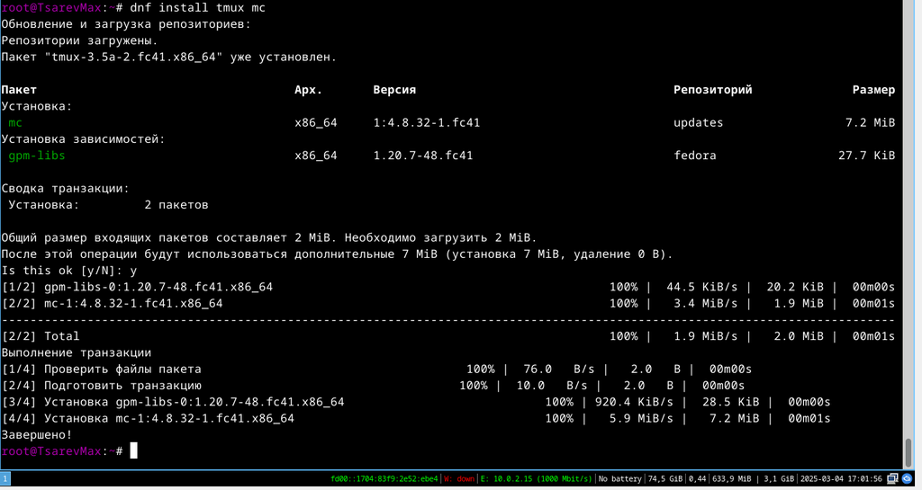

sudo dnf -y group install development-tools

Обновляю все пакеты

sudo dnf -y update

Программы для удобства работы в консоли:

sudo dnf -y install tmux mc

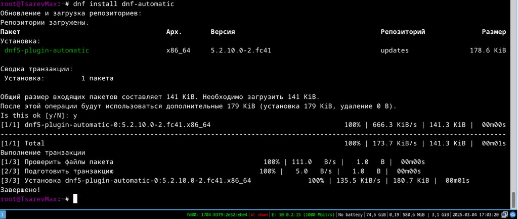

Автоматическое обновление

Установка программного обеспечения:

sudo dnf -y install dnf-automatic

[figure not shown]

## Настройка машины

Задаю необходимую конфигурацию в файле /etc/dnf/automatic.conf.

sudo systemctl enable –now dnf-automatic.timer

В файле /etc/selinux/config заменяю значение SELINUX=enforcing на значение SELINUX=permissive

Перегружаю виртуальную машину:

sudo systemctl reboot

## Создание конфигурационного файла

оздаю конфигурационный файл ~/.config/sway/config.d/95-system-keyboard-config.conf:

mkdir -p ~/.config/sway touch ~/.config/sway/config.d/95-system-keyboard-config.conf

редактирую конфигурационный файл ~/.config/sway/config.d/95-system-keyboard-config.conf:

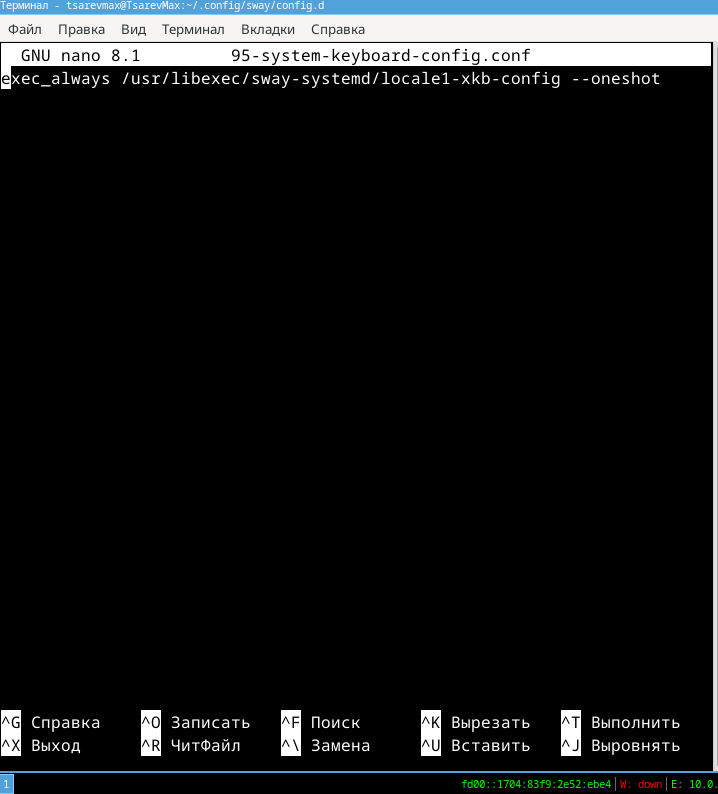

[figure not shown]

## Редактирование

Отредактировал конфигурационный файл /etc/X11/xorg.conf.d/00-keyboard.conf:

Section “InputClass” Identifier “system-keyboard” MatchIsKeyboard “on” Option “XkbLayout” “us,ru” Option “XkbVariant” “,winkeys” Option “XkbOptions” “grp:rctrl_toggle,compose:ralt,terminate:ctrl_alt_bksp” EndSection

## Установка pandoc

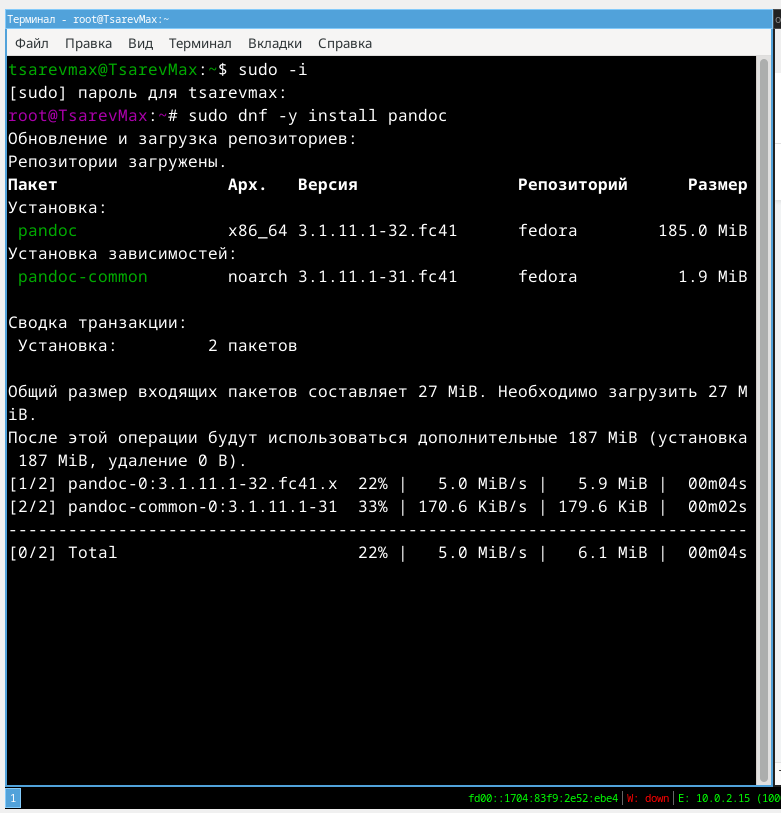

## Устанавливаю texlive

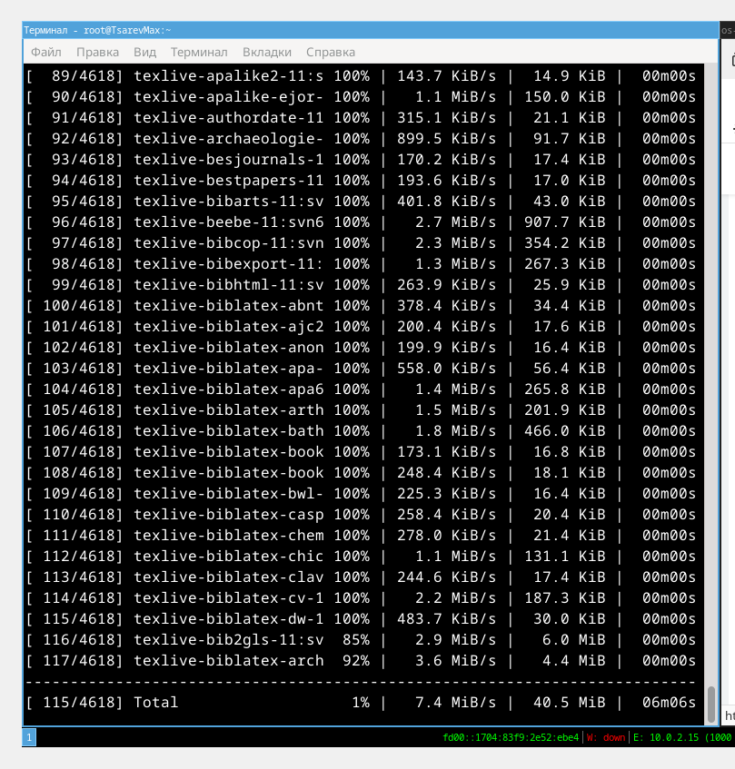

## Выполнение задания

Узнаю всю информацию о системе

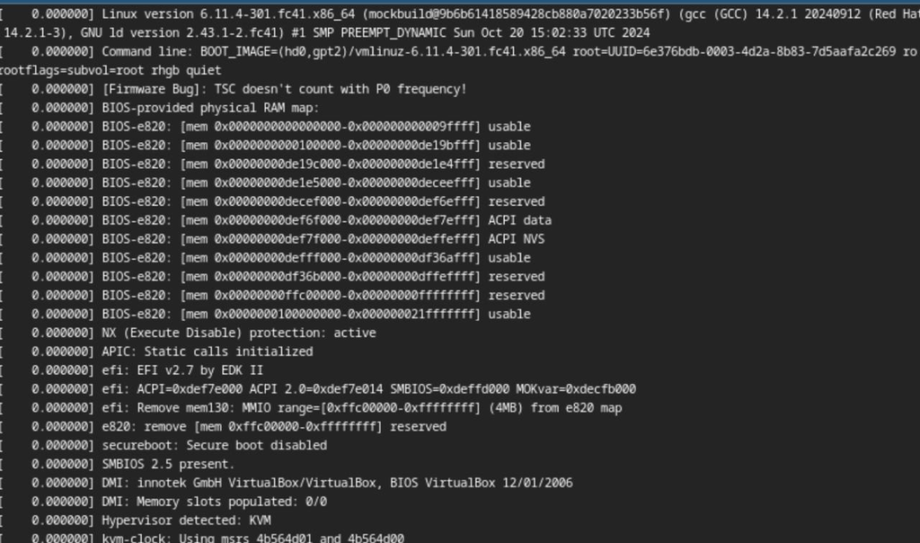